# European Restaurant Deepdive - Project Code

Project Report for STAT 303-1 Fall 2024

Author

Robert Yao, Grace Wu, Yingshan Chen, Maddie Wang

Published

December 10, 2024

Abstract

*This file contains the code for the project*.

**Rules for the code:**

- Include all the code you used for your report in this file. The code for any section in the report should go under the same section in this file.
- Any missing code will result in -20% from its corresponding section in the report.
- Any irrelevant code will result in -20% from its corresponding section in the report.
- Make sure that you run your code before rendering, so all the necessary visual/numeric outputs are visible.
- Any code that is not properly run or throws errors will be considered missing/irrelevant.

## 3) Data

```python
# import necessary packages
import pandas as pd
import numpy as np
import seaborn as sns
import matplotlib.pyplot as plt
import geopandas as gpd
import warnings
import folium
```

```python
data = pd.read_csv('tripadvisor_european_restaurants.csv', low_memory = False)
warnings.filterwarnings('ignore')
```

```python
pd.set_option('display.max_columns', None)
pd.set_option('display.max_rows', None)
data.head()
```

|  | restaurant_link | restaurant_name | original_location | country | region | province | city | address | latitude | longitude | claimed | awards | popularity_detailed | popularity_generic | top_tags | price_level | price_range | meals | cuisines | special_diets | features | vegetarian_friendly | vegan_options | gluten_free | original_open_hours | open_days_per_week | open_hours_per_week | working_shifts_per_week | avg_rating | … |
| --- | --- | --- | --- | --- | --- | --- | --- | --- | --- | --- | --- | --- | --- | --- | --- | --- | --- | --- | --- | --- | --- | --- | --- | --- | --- | --- | --- | --- | --- | --- |
| 0 | g10001637-d10002227 | Le 147 | ["Europe", "France", "Nouvelle-Aquitaine", "Ha... | France | Nouvelle-Aquitaine | Haute-Vienne | Saint-Jouvent | 10 Maison Neuve, 87510 Saint-Jouvent France | 45.961674 | 1.169131 | Claimed | NaN | #1 of 2 Restaurants in Saint-Jouvent | #1 of 2 places to eat in Saint-Jouvent | Cheap Eats, French | € | NaN | Lunch, Dinner | French | NaN | Reservations, Seating, Wheelchair Accessible, ... | N | N | N | NaN | NaN | NaN | NaN | 4.0 | … |
| 1 | g10001637-d14975787 | Le Saint Jouvent | ["Europe", "France", "Nouvelle-Aquitaine", "Ha... | France | Nouvelle-Aquitaine | Haute-Vienne | Saint-Jouvent | 16 Place de l Eglise, 87510 Saint-Jouvent France | 45.957040 | 1.205480 | Unclaimed | NaN | #2 of 2 Restaurants in Saint-Jouvent | #2 of 2 places to eat in Saint-Jouvent | Cheap Eats | € | NaN | NaN | NaN | NaN | NaN | N | N | N | NaN | NaN | NaN | NaN | 4.0 | … |
| 2 | g10002858-d4586832 | Au Bout du Pont | ["Europe", "France", "Centre-Val de Loire", "B... | France | Centre-Val de Loire | Berry | Rivarennes | 2 rue des Dames, 36800 Rivarennes France | 46.635895 | 1.386133 | Claimed | NaN | #1 of 1 Restaurant in Rivarennes | #1 of 1 places to eat in Rivarennes | Cheap Eats, French, European | € | NaN | Dinner, Lunch, Drinks | French, European | NaN | Reservations, Seating, Table Service, Wheelcha... | N | N | N | NaN | NaN | NaN | NaN | 5.0 | … |
| 3 | g10002986-d3510044 | Le Relais de Naiade | ["Europe", "France", "Nouvelle-Aquitaine", "Co... | France | Nouvelle-Aquitaine | Correze | Lacelle | 9 avenue Porte de la Correze 19170, 19170 Lace... | 45.642610 | 1.824460 | Claimed | NaN | #1 of 1 Restaurant in Lacelle | #1 of 1 places to eat in Lacelle | Cheap Eats, French | € | NaN | Lunch, Dinner | French | NaN | Reservations, Seating, Serves Alcohol, Table S... | N | N | N | NaN | NaN | NaN | NaN | 4.0 | … |
| 4 | g10022428-d9767191 | Relais Du MontSeigne | ["Europe", "France", "Occitanie", "Aveyron", "... | France | Occitanie | Aveyron | Saint-Laurent-de-Levezou | route du Montseigne, 12620 Saint-Laurent-de-Le... | 44.208860 | 2.960470 | Unclaimed | NaN | #1 of 1 Restaurant in Saint-Laurent-de-Levezou | #1 of 1 places to eat in Saint-Laurent-de-Levezou | Mid-range, French | €€-€€€ | NaN | Lunch, Dinner | French | NaN | Reservations, Seating, Wheelchair Accessible, ... | N | N | N | NaN | NaN | NaN | NaN | 4.5 | … |

## 5) Data Cleaning

### a) Cleaning 1

*By Robert Yao*

```python
# accessing data for robert's analysis
rdata = data.copy()

# clean column names
rdata.columns = rdata.columns.str.lower().str.replace(' ', '_')

# accessing geopandas dataset
gdf = gpd.read_file("https://naciscdn.org/naturalearth/110m/cultural/ne_110m_admin_0_countries.zip")

# access france, removing irrelevant dependencies
gdf_f = gdf.loc[(gdf['SOVEREIGNT'] == 'France') & (gdf['TYPE'] == 'Country'), 'geometry']

# access italy
gdf_i = gdf.loc[(gdf['SOVEREIGNT'] == 'Italy'), 'geometry']
```

##### Component 1 (Rating comparison)

```python
# creating award status as column
rdata['award_bin'] = np.where(rdata['awards'].notna(), 'Award-Winning', 'No Award')

# checking data
# missing at least one rating
missing_rows = rdata[(rdata['food'].isna()) | (rdata['service'].isna()) | (rdata['value'].isna())].shape[0]

# print missing percentage
print(missing_rows / rdata.shape[0] * 100)

# define imputation function
def mean_impute(x):
    return x.fillna(x.mean(numeric_only=True))

# impute by region, avg_rating, award_bin
rdata[['food', 'service', 'value']] = rdata.groupby(['region', 'avg_rating', 'award_bin'],
                                                    group_keys = False)[['food', 'service', 'value']].apply(mean_impute)

# recheck data
# missing at least one rating
missing_rows = rdata[(rdata['food'].isna()) | (rdata['service'].isna()) | (rdata['value'].isna())].shape[0]

# print missing percentage
print(missing_rows / rdata.shape[0] * 100)
```

```
44.92083696004327
13.434871981369712
```

##### Component 2 (Geographical distribution)

```python
# seeing which countries have the most award-winning restaurants
rdata.groupby('country')[['awards']].count().sort_values(by = 'awards', ascending = False).head(5)
```

| country | awards |
| --- | --- |
| Italy | 65488 |
| England | 43789 |
| France | 43250 |
| Spain | 35870 |
| Germany | 12884 |

```python
# checking missing lon/lat
print(rdata[rdata['latitude'].isna() | rdata['longitude'].isna()].shape[0])

# award-winning, French, missing lon/lat
afm = rdata[(rdata['latitude'].isna() | rdata['longitude'].isna()) & (rdata['awards'].notna()) & (rdata['country'] == 'France')].shape[0]

# award-winning, French, tot
af = rdata[(rdata['awards'].notna()) & (rdata['country'] == 'France')].shape[0]

# find percentage
print(round((afm / af) * 100, 2))

# award-winning, Italian, missing lon/lat
aim = rdata[(rdata['latitude'].isna() | rdata['longitude'].isna()) & (rdata['awards'].notna()) & (rdata['country'] == 'Italy')].shape[0]

# award-winning, Italian, tot
ai = rdata[(rdata['awards'].notna()) & (rdata['country'] == 'Italy')].shape[0]

# find percentage
print(round((aim / ai) * 100, 2))

# filtering missing lat/long
map_data = rdata.dropna(subset = ['latitude', 'longitude'])
```

```
15790
0.13
0.06
```

### b) Cleaning 2

*By Grace Wu*

##### 1) analysis of relevant missing data

```python
gdata = data.copy()

# keep only necessary columns used below
columns = ['restaurant_name', 'country', 'cuisines', 'avg_rating']
data_clean = gdata[columns]

# find percent of restaurants with missing values
missing_data = data_clean[columns].isna().sum()
print(missing_data / data_clean.shape[0] * 100)

# find percent of restaurants with missing values in both "cuisines" and "avg_rating" columns
both_nans = data_clean[data_clean['cuisines'].isna() & data_clean['avg_rating'].isna()]
print(both_nans.shape[0] / data_clean.shape[0] * 100)
```

```
restaurant_name     0.000092
country             0.000000
cuisines           15.608590
avg_rating          8.919722
dtype: float64
3.579851153362987
```

##### 2) “cuisines” column cleaning & wrangling

```python
# drop rows with missing cuisines
data_clean = data_clean.dropna(subset=['cuisines'])

# normalize to lowercase, strip whitespace
data_clean['restaurant_name'] = data_clean['restaurant_name'].str.strip().str.lower()
data_clean['cuisines'] = data_clean['cuisines'].str.strip().str.lower()

# split "cuisines" column into list of cuisines, strip whitespace
data_clean['cuisine_list'] = data_clean['cuisines'].str.split(',')
data_clean['cuisine_list'] = data_clean['cuisine_list'].apply(lambda x: [i.strip() for i in x])

# flatten list of all cuisines across all restaurants
all_cuisines = [cuisine for sublist in data_clean['cuisine_list'] for cuisine in sublist]

# count frequency of each cuisine
cuisine_counts = pd.Series(all_cuisines).value_counts()

# function to get cuisine with highest global count
def most_frequent_cuisine(cuisine_list):
    return max(cuisine_list, key=lambda x: cuisine_counts.get(x, 0))

# apply function to get most frequent cuisine for each restaurant
data_clean['cuisine'] = data_clean['cuisine_list'].apply(most_frequent_cuisine)
```

##### 3) “avg_rating” column cleaning

```python
# impute missing avg_rating values with mean based on cuisine
mean_ratings = data_clean.groupby('cuisines')['avg_rating'].mean()

data_clean['avg_rating'] = data_clean['avg_rating'].fillna(data_clean['cuisines'].map(mean_ratings))

# drop rows with remaining missing avg_rating
data_clean = data_clean.dropna(subset=['avg_rating'])
```

### c) Cleaning 3

*By Yingshan Chen*

##### 1) Analysis of missing data

```python
ydata = data.copy()
cols = ['avg_rating', 'awards', 'restaurant_name', 'restaurant_link', 'country']
missing = ydata[cols].isna().sum()
print(missing / ydata[cols].shape[0] * 100)
```

```
avg_rating          8.919722
awards             75.712227
restaurant_name     0.000092
restaurant_link     0.000000
country             0.000000
dtype: float64
```

##### 2) “awards” & “avg_rating” column cleaning & imputing

```python
#Defining a function to create a list of the non-python string list in the awards to get the count.
def count_awards(x):
    # Check if x is a string and if it contains any awards
    if isinstance(x, str):
        # Split the string by commas and count the number of non-empty items, trimming whitespace
        return len([award.strip() for award in x.split(',') if award.strip()])
    return 0  # If it's not a string or is empty, return 0

# Apply the function to count the number of awards
ydata['num_awards'] = ydata['awards'].apply(count_awards)


#Imputing the missing values of avg_rating
def mean_impute(x):
    return x.fillna(x.mean(numeric_only=True))

ydata['avg_rating'] = ydata.groupby('country', group_keys=False)['avg_rating'].apply(mean_impute)
```

```python
# Perform the grouping and aggregation
group_data = ydata.groupby('restaurant_link').agg(
    restaurant_name=('restaurant_name', 'first'),
    num_awards=('num_awards', 'sum'),  # Sum of the awards counts
    avg_ratings=('avg_rating', 'mean')  # avg ratings
).reset_index()

# Drop rows where 'num_awards' is 0 (or NaN) — meaning no awards
cleaned_group_data = group_data[group_data['num_awards'] > 0] #grouped data
cleaned_group_data = cleaned_group_data.reset_index(drop=True)

cleaned_data = ydata[ydata['num_awards'] > 0] #entire df of awardwinning restaurants
cleaned_data = cleaned_data.reset_index(drop=True)
```

### d) Cleaning 4

*By Maddie Wang*

##### 1) finding how many restaurants have missing ratings

```python
# finding the number of restaurants that don't have any rating votes
missing_ratings = data[['excellent', 'very_good', 'average', 'poor', 'terrible']].isna().sum()
print(missing_ratings)
print()

# calculating what percentage the missing values are of the entire dataset
missing_ratings_pct = missing_ratings/data.shape[0] * 100
print(missing_ratings_pct)
```

```
excellent    95193
very_good    95193
average      95193
poor         95193
terrible     95193
dtype: int64

excellent    8.78653
very_good    8.78653
average      8.78653
poor         8.78653
terrible     8.78653
dtype: float64
```

##### 2) analyzing how the restaurants with missing ratings are distributed across countries

```python
# getting a list of the unique countries in the data set
countries = data['country'].unique()

# finding the rows where there are no rating votes
missing_rating_rows = data[['excellent', 'very_good', 'average', 'poor', 'terrible']].isna().all(axis=1)

# counting the number of restaurants with missing ratings per country
missing_by_country = data.loc[missing_rating_rows].groupby('country').size()

# calculating the total number of restaurants per country
total_by_country = data.groupby('country').size()

# calculating the percentage of restaurants with missing ratings
missing_pct_by_country = (missing_by_country / total_by_country) * 100
print(missing_pct_by_country)
print()

# finding the top 3 countries with the most missing observations
print(missing_pct_by_country.sort_values(ascending=False)[0:3])
```

```
country
Austria             11.407234
Belgium              6.950361
Bulgaria            14.410383
Croatia              5.994030
Czech Republic      14.227971
Denmark              8.328940
England              7.899448
Finland             13.958220
France               6.851141
Germany             11.604658
Greece               7.691852
Hungary              9.393083
Ireland              7.587253
Italy                7.292125
Northern Ireland     7.099615
Poland              15.871731
Portugal             9.806087
Romania             17.878092
Scotland             6.078087
Slovakia            18.889673
Spain                9.201862
Sweden               9.803288
The Netherlands      9.418636
Wales                6.404642
dtype: float64

country
Slovakia    18.889673
Romania     17.878092
Poland      15.871731
dtype: float64
```

## 6) Data Analysis

### a) Analysis 1

*By Robert Yao*

##### Component 1 (Rating comparison)

```python
# melting data for plotting purposes
data_long = rdata.melt(id_vars = ['award_bin'], value_vars = ['food', 'service', 'value'],
                       var_name = 'rating_type', value_name = 'rating')

# calculate average ratings by award status for each rating type
avg_ratings = data_long.groupby(['award_bin', 'rating_type']).agg(avg_rating = ('rating', 'mean')).reset_index()
```

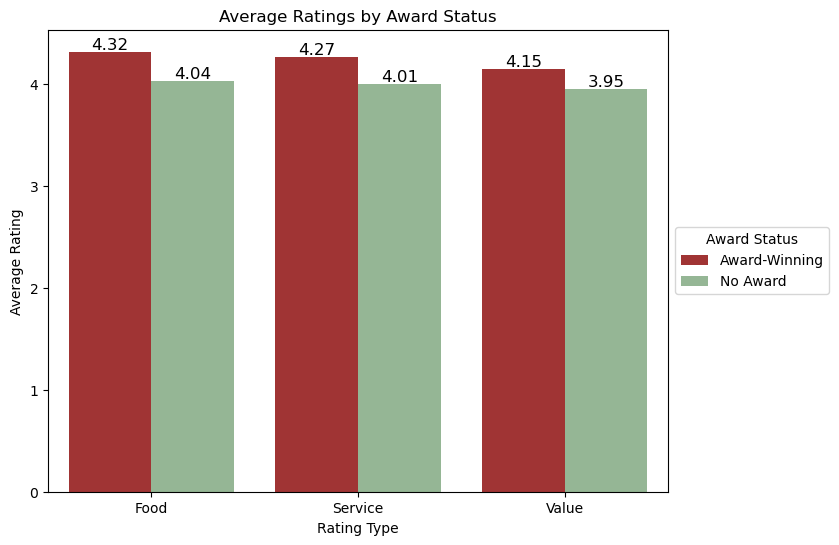

```python
# plotting average ratings by award status
# set size
plt.figure(figsize = (8, 6))

# create side-by-side barplot
sns.barplot(data = avg_ratings, x = 'rating_type', y = 'avg_rating', hue = 'award_bin', dodge = True,
            palette = ['firebrick', 'darkseagreen'])

# place legend
plt.legend(title = 'Award Status', loc = 'center left', bbox_to_anchor = (1, 0.5))

# label bars
for p in plt.gca().patches:
    # skip labels for 0 ht rectangles
    if p.get_height() != 0:
        # labeling bars based on bar dims
        plt.gca().annotate(str(round(p.get_height(), 2)), (p.get_x() + p.get_width() / 2, p.get_height()),
                           ha = 'center', va = 'center', fontsize = 12, color = 'black', xytext=(0, 5), textcoords='offset points')
    else:
        continue

# plot labels
plt.title("Average Ratings by Award Status")
plt.xlabel("Rating Type")
plt.ylabel("Average Rating")
plt.xticks([0, 1, 2], ['Food', 'Service', 'Value'])

plt.show()
```

##### Component 2 (Geographical distribution)

```python
# converting restaurant lat/long data to gdf
res_gdf = gpd.GeoDataFrame(map_data, geometry =
                           gpd.points_from_xy(map_data['longitude'], map_data['latitude']), crs = "EPSG:4326")

# creating location and population data for french cities
cities_data = pd.DataFrame({
    'city': ["Paris", "Marseille", "Lyon", "Toulouse", "Nice", "Nantes", "Strasbourg", "Montpellier", "Bordeaux"],
    'lat': [48.8566, 43.2965, 45.75, 43.6047, 43.7102, 47.2186, 48.5734, 43.6111, 44.8378],
    'lon': [2.3522, 5.3811, 4.85, 1.4442, 7.262, -1.5536, 7.752, 3.8767, -0.5792],
    'population': [2130000, 870000, 520000, 500000, 350000, 320000, 300000, 290000, 260000]
})

# creating location and population data for italian cities
i_cities_data = pd.DataFrame({
    'city': ["Rome", "Milan", "Naples", "Turin", "Palermo", "Genoa", "Bologna", "Florence", "Venice", "Verona"],
    'lat': [41.9028, 45.4642, 40.8518, 45.0703, 38.1157, 44.4056, 44.4949, 43.7696, 45.4408, 45.4384],
    'lon': [12.4964, 9.1900, 14.2681, 7.6869, 13.3615, 8.9463, 11.3426, 11.2558, 12.3155, 10.9916],
    'population': [2754719, 1371850, 911697, 846926, 628894, 561947, 390518, 363837, 250369, 255643]
})

# converting city lat/long data to gdf
cities_gdf = gpd.GeoDataFrame(cities_data, geometry =
                                    gpd.points_from_xy(cities_data['lon'], cities_data['lat']), crs = "EPSG:4326")
i_cities_gdf = gpd.GeoDataFrame(i_cities_data, geometry =
                                    gpd.points_from_xy(i_cities_data['lon'], i_cities_data['lat']), crs = "EPSG:4326")

# extracting award-winning french restaurants
france_restaurants = res_gdf[res_gdf['country'] == 'France']
france_award_restaurants = france_restaurants[france_restaurants['awards'].notna()]

# extracting award-winning italian restaurants
italy_restaurants = res_gdf[res_gdf['country'] == 'Italy']
italy_award_restaurants = italy_restaurants[italy_restaurants['awards'].notna()]
```

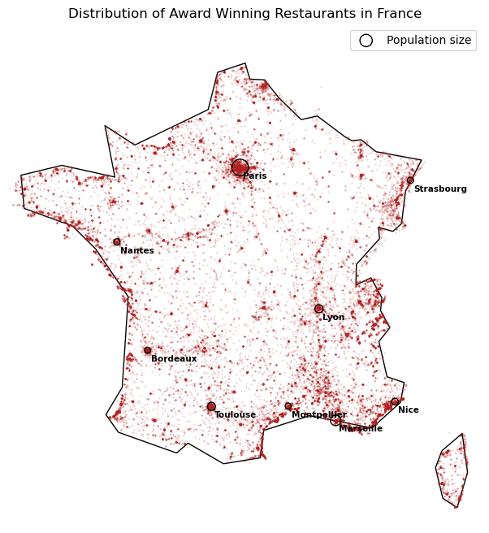

```python
# set plot size
fig, ax = plt.subplots(figsize = (8, 8))

# plotting french map
gdf_f.plot(ax = ax, color = 'white', edgecolor = 'black')

# adding restaurants and cities
france_award_restaurants.plot(ax = ax, marker = 'o', color = 'firebrick', alpha = 0.3, markersize = 0.15)

# city circle size based on city population
cities_gdf.plot(ax = ax, marker = 'o', facecolors = 'none', edgecolors = 'black',
                markersize = cities_gdf['population'] / 10000,
                label = 'Population size')
plt.legend()

# label cities by name, shifting text for clarity
for idx, row in cities_gdf.iterrows():
    ax.text(row['lon'] + 0.1, row['lat'] - 0.1, row['city'], fontsize = 7.5, ha = 'left', va = 'top', color = 'black', fontweight = 'demibold')

# setting limits to exclude external territories
plt.xlim(-5, 10)
plt.ylim(41, 52)

# remove unnecessary axes
plt.axis('off')
plt.title('Distribution of Award Winning Restaurants in France')

plt.show()
```

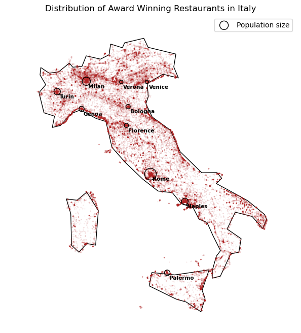

```python
# set plot size
fig2, ax2 = plt.subplots(figsize = (8, 8))

# plotting italian map
gdf_i.plot(ax = ax2, color = 'white', edgecolor = 'black')

# adding restaurants and cities
italy_award_restaurants.plot(ax = ax2, marker = 'o', color = 'firebrick', alpha = 0.2, markersize = 0.1)

# city circle size based on city population
i_cities_gdf.plot(ax = ax2, marker = 'o', facecolors = 'none', edgecolors = 'black',
                  markersize = i_cities_gdf['population'] / 10000, label = 'Population size')
plt.legend()

# label cities by name, shifting text for clarity
for idx, row in i_cities_gdf.iterrows():
    ax2.text(row['lon'] + 0.1, row['lat'] - 0.1, row['city'], fontsize = 7.5, ha = 'left', va = 'top', color = 'black', fontweight = 'demibold')

# setting limits
plt.xlim(5, 20)
plt.ylim(36, 48)

# remove unnecessary axes
plt.axis('off')
plt.title('Distribution of Award Winning Restaurants in Italy')

plt.show()
```

### b) Analysis 2

*By Grace Wu*

##### 1) bar chart: distribution of restaurants by cuisine

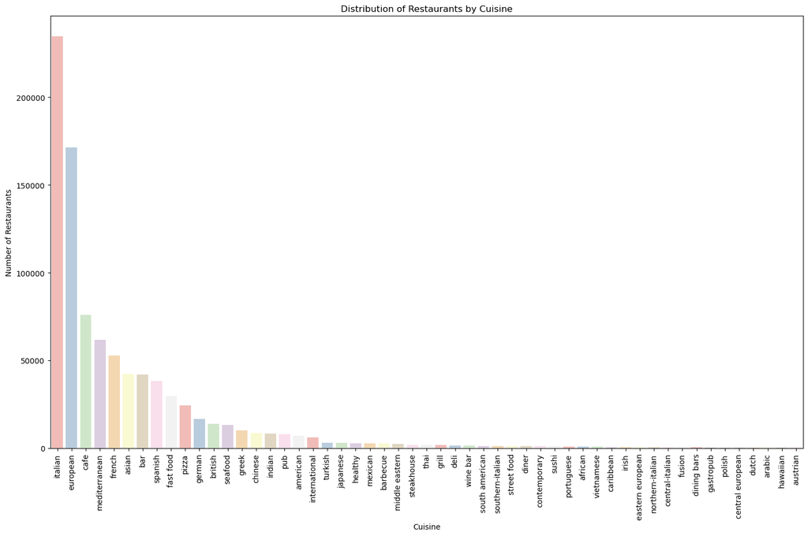

```python
# count frequency of cuisine type, limit visualization to counts over 200
cuisine_counts = data_clean['cuisine'].value_counts()
cuisine_counts = cuisine_counts[cuisine_counts > 200]

plt.figure(figsize=(15,10))
sns.barplot(x=cuisine_counts.index, y=cuisine_counts.values, palette='Pastel1')
plt.title('Distribution of Restaurants by Cuisine')
plt.xlabel('Cuisine')
plt.ylabel('Number of Restaurants')
plt.xticks(rotation=90)
plt.tight_layout()
plt.show()
```

##### 2) boxplot: rating distribution by cuisine

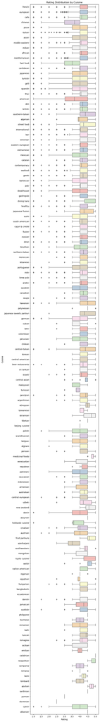

```python
plt.figure(figsize=(7,50))
sns.boxplot(x='avg_rating', y='cuisine', data=data_clean, palette='Pastel1')
plt.title('Rating Distribution by Cuisine')
plt.xlabel('Rating')
plt.ylabel('Cuisine')
plt.tight_layout()
plt.show()
```

```python
# calculate relevant statistics for each cuisine
boxplot_stats = data_clean.groupby('cuisine')['avg_rating'].describe()

# add number of outliers for each cuisine
def count_outliers(cuisine_data):
    q1 = cuisine_data['avg_rating'].quantile(0.25)
    q3 = cuisine_data['avg_rating'].quantile(0.75)

    iqr = q3 - q1

    lower_bound = q1 - 1.5 * iqr
    upper_bound = q3 + 1.5 * iqr

    return ((cuisine_data['avg_rating'] < lower_bound) | (cuisine_data['avg_rating'] > upper_bound)).sum()

# calculate number of outliers for each cuisine
boxplot_stats['outliers'] = data_clean.groupby('cuisine').apply(count_outliers)

high_mean = boxplot_stats.sort_values(by='50%', ascending=False).head(10)
low_mean = boxplot_stats.sort_values(by='50%', ascending=False).tail(10)

pd.concat([high_mean,low_mean], axis=0)
```

| cuisine | count | mean | std | min | 25% | 50% | 75% | max | outliers |
| --- | --- | --- | --- | --- | --- | --- | --- | --- | --- |
| neapolitan | 3.0 | 4.833333 | 0.288675 | 4.5 | 4.750000 | 5.000000 | 5.000 | 5.0 | 0 |
| kyoto cuisine | 3.0 | 4.500000 | 0.866025 | 3.5 | 4.250000 | 5.000000 | 5.000 | 5.0 | 0 |
| calabrian | 1.0 | 5.000000 | NaN | 5.0 | 5.000000 | 5.000000 | 5.000 | 5.0 | 0 |
| apulian | 2.0 | 4.750000 | 0.353553 | 4.5 | 4.625000 | 4.750000 | 4.875 | 5.0 | 0 |
| medicinal foods | 15.0 | 4.766667 | 0.175933 | 4.5 | 4.750000 | 4.750000 | 4.875 | 5.0 | 3 |
| ukrainian | 4.0 | 4.500000 | 0.707107 | 3.5 | 4.250000 | 4.750000 | 5.000 | 5.0 | 0 |
| fruit parlours | 25.0 | 4.607143 | 0.328461 | 4.0 | 4.500000 | 4.607143 | 5.000 | 5.0 | 0 |
| new zealand | 8.0 | 4.583333 | 0.415474 | 4.0 | 4.375000 | 4.583333 | 5.000 | 5.0 | 0 |
| chilean | 9.0 | 4.277778 | 0.565194 | 3.0 | 4.000000 | 4.500000 | 4.500 | 5.0 | 1 |
| colombian | 12.0 | 4.333333 | 0.492366 | 3.5 | 4.000000 | 4.500000 | 4.500 | 5.0 | 0 |
| algerian | 20.0 | 3.884615 | 1.148842 | 1.0 | 3.884615 | 3.942308 | 4.500 | 5.0 | 3 |
| chinese | 8578.0 | 3.676201 | 0.809512 | 1.0 | 3.000000 | 3.654656 | 4.000 | 5.0 | 117 |
| american | 7086.0 | 3.716778 | 0.862972 | 1.0 | 3.035714 | 3.643657 | 4.500 | 5.0 | 0 |
| hokkaido cuisine | 7.0 | 3.600000 | 1.271482 | 1.0 | 3.550000 | 3.600000 | 4.250 | 5.0 | 1 |
| azerbaijani | 7.0 | 3.500000 | 0.577350 | 2.5 | 3.250000 | 3.500000 | 4.000 | 4.0 | 0 |
| malaysian | 3.0 | 3.833333 | 0.577350 | 3.5 | 3.500000 | 3.500000 | 4.000 | 4.5 | 0 |
| fast food | 29560.0 | 3.533023 | 0.918518 | 1.0 | 3.000000 | 3.500000 | 4.000 | 5.0 | 313 |
| cuban | 9.0 | 3.666667 | 0.829156 | 2.5 | 3.500000 | 3.500000 | 4.000 | 5.0 | 3 |
| yunnan | 1.0 | 3.000000 | NaN | 3.0 | 3.000000 | 3.000000 | 3.000 | 3.0 | 0 |
| slovenian | 1.0 | 2.500000 | NaN | 2.5 | 2.500000 | 2.500000 | 2.500 | 2.5 | 0 |

##### 3) heatmap: average rating by cuisine and country

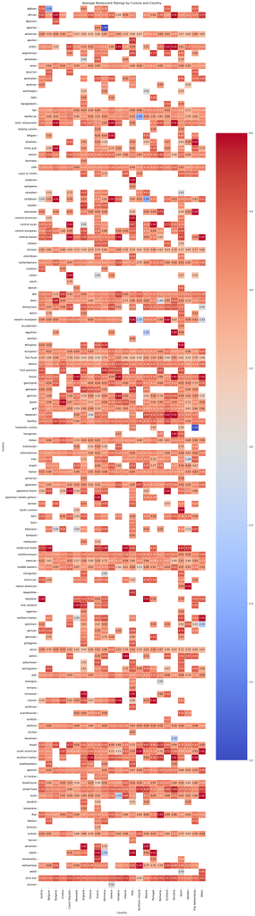

```python
cuisine_location_ratings = data_clean.groupby(['cuisine', 'country'])['avg_rating'].mean().unstack()

plt.figure(figsize=(14,50))
sns.heatmap(cuisine_location_ratings, cmap='coolwarm', annot=True, fmt='.2f', linewidths=0.5)
plt.title('Average Restaurant Ratings by Cuisine and Country')
plt.xlabel('Country')
plt.ylabel('Cuisine')
plt.tight_layout()
plt.show()
```

### c) Analysis 3

*By Yingshan Chen*

##### 1) Bar Plot: Describing the correlation between average rating and number of awards

###### Data Vis

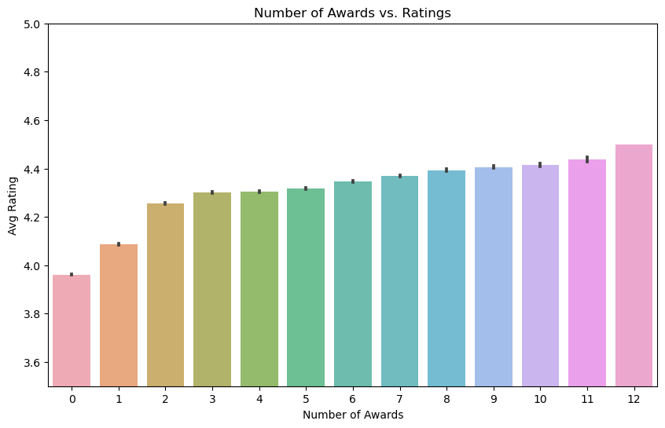

```
Correlation between number of awards and average ratings: 0.19
```

```python
# Create the bar plot for general
plt.figure(figsize=(10, 6))
sns.barplot(data=group_data, x='num_awards', y='avg_ratings', alpha=0.8)
plt.ylim(3.5, 5)
plt.title('Number of Awards vs. Ratings')
plt.xlabel('Number of Awards')
plt.ylabel('Avg Rating')
plt.show()

# Correlation between number of awards and  ratings
award_rating_corr = group_data['num_awards'].corr(group_data['avg_ratings'])
print(f"Correlation between number of awards and average ratings: {award_rating_corr:.2f}")
```

##### 2) Barplots: Countries to visit with the highest awards and averages

###### Data Wrangling

```python
geo_data = cleaned_data.groupby('country').agg(
    restaurant_name=('restaurant_name', 'first'),
    num_awards=('num_awards', 'sum'),  # Sum of the awards counts
    avg_ratings=('avg_rating', 'mean')  # avg ratings
).reset_index()

# 1. Top Restaurants by Country (Number of Awards)
country_awards = geo_data.groupby('country')['num_awards'].sum().reset_index(name='total_awards')
country_awards = country_awards.sort_values(by='total_awards', ascending=False)
```

###### Data Vis

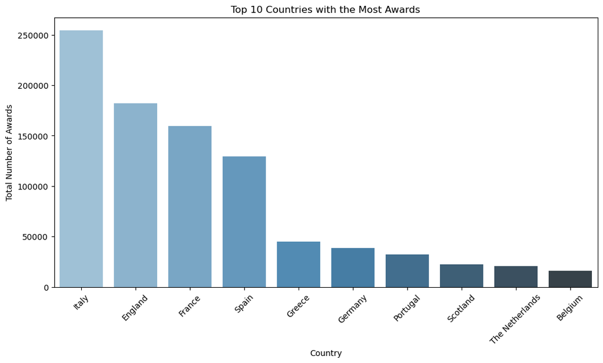

```python
# Plotting total awards by country
plt.figure(figsize=(12, 6))
sns.barplot(data=country_awards.head(10), x='country', y='total_awards', palette='Blues_d')
plt.title('Top 10 Countries with the Most Awards')
plt.xlabel('Country')
plt.ylabel('Total Number of Awards')
plt.xticks(rotation=45)
plt.show()
```

###### Data Wrangling pt.2

```python
geo_data_all = ydata.groupby('country').agg(
    avg_ratings=('avg_rating', 'mean')  # avg ratings
).reset_index()

top_10_countries = geo_data_all.sort_values(by='avg_ratings', ascending=False).head(10)
```

###### Data Vis pt.2

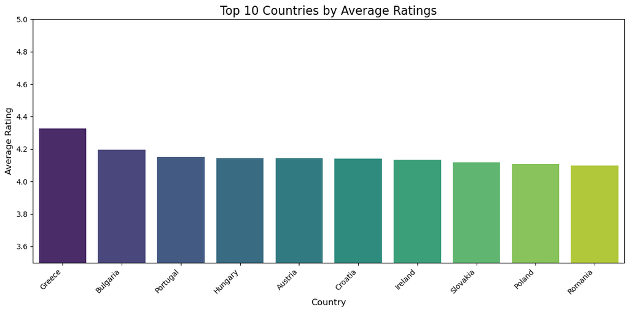

```python
# Creating a plot of the top 10 by avgs
plt.figure(figsize=(12, 6))
sns.barplot(data=top_10_countries, x='country', y='avg_ratings', palette='viridis')
plt.title('Top 10 Countries by Average Ratings', fontsize=16)
plt.xlabel('Country', fontsize=12)
plt.ylabel('Average Rating', fontsize=12)
plt.xticks(rotation=45, ha='right')  # Rotate x-axis labels for readability
plt.ylim(3.5, 5)
plt.tight_layout()
plt.show()
```

### d) Analysis 4

*By Maddie Wang*

##### Part 1: Data Wrangling

```python
mdata = data.copy()

# creating a new column distinguishing which rating has the highest number of votes (i.e most commonly agreed upon rating)
mdata['highest_voted_rating'] = mdata[['excellent', 'very_good', 'average', 'poor', 'terrible']].idxmax(axis=1)

# creating a mini dataframe of just the rankings
rankings_df = mdata[['country', 'restaurant_name', 'excellent', 'very_good', 'average', 'poor', 'terrible', 'highest_voted_rating']]
rankings_df.head()

# counting how many restaurants in each country fall into each rating category
country_ratings = rankings_df.groupby(['country', 'highest_voted_rating'])[['highest_voted_rating']].size().reset_index(name='votes')

# using pivot to make each row a country for better readibility
country_ratings = country_ratings.pivot(index='country', columns='highest_voted_rating', values='votes')
```

##### Part 1: Data Visualization

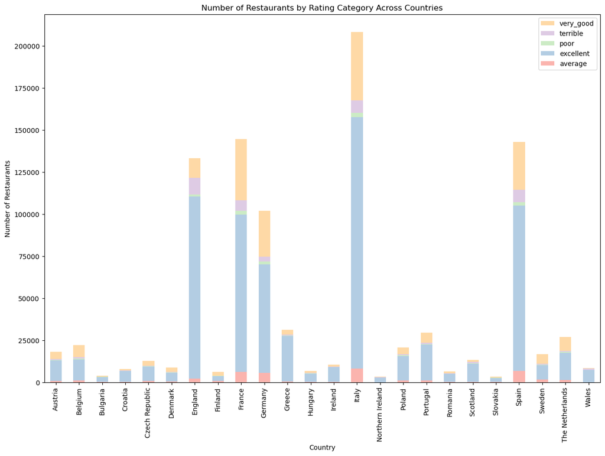

```python
# creating a stacked bar plot
country_ratings.plot.bar(stacked=True, color=sns.color_palette("Pastel1"))

# adjusting the legend, adding labels and resizing the graph
a = plt.legend(bbox_to_anchor=(1,1), reverse=True)
plt.xlabel('Country')
plt.ylabel('Number of Restaurants')
plt.title("Number of Restaurants by Rating Category Across Countries")
a.figure.set_figwidth(15)
a.figure.set_figheight(10)
plt.show()
```

##### Part 1: Numeric Representation

```python
# calculating the percentage breakdown per country of how many restaurants fall into each rating category

# 1) getting the total number of restaurants per country
country_ratings['total restaurants'] = country_ratings[['terrible', 'poor', 'average', 'very_good', 'excellent']].sum(axis=1)

# 2) writing a function that will calculate the rating category percentage breakdown per country
def pct_calc(row):
    ratings = ['terrible', 'poor', 'average', 'very_good', 'excellent']
    pct = (row[ratings] / row['total restaurants'] * 100).round(2)
    return pct

# 3) applying the function to create a df
pct_df = country_ratings.apply(pct_calc, axis=1)
pct_df
```

| highest_voted_rating country | terrible | poor | average | very_good | excellent |
| --- | --- | --- | --- | --- | --- |
| Austria | 2.48 | 1.17 | 4.39 | 23.97 | 67.98 |
| Belgium | 3.40 | 1.85 | 5.28 | 32.54 | 56.92 |
| Bulgaria | 3.40 | 1.20 | 3.27 | 12.03 | 80.10 |
| Croatia | 3.59 | 0.95 | 2.34 | 9.15 | 83.97 |
| Czech Republic | 4.15 | 2.31 | 7.27 | 21.32 | 64.95 |
| Denmark | 3.63 | 2.36 | 6.99 | 29.09 | 57.93 |
| England | 7.48 | 0.76 | 1.68 | 8.84 | 81.24 |
| Finland | 1.48 | 2.11 | 11.29 | 36.70 | 48.42 |
| France | 4.31 | 1.64 | 4.20 | 25.12 | 64.73 |
| Germany | 2.68 | 1.66 | 5.60 | 26.84 | 63.22 |
| Greece | 1.65 | 0.73 | 1.87 | 9.27 | 86.49 |
| Hungary | 4.52 | 1.66 | 4.25 | 16.50 | 73.07 |
| Ireland | 4.28 | 0.57 | 1.42 | 8.86 | 84.87 |
| Italy | 3.52 | 1.18 | 3.94 | 19.58 | 71.78 |
| Northern Ireland | 7.35 | 0.98 | 1.75 | 7.58 | 82.35 |
| Poland | 3.26 | 1.82 | 5.22 | 19.57 | 70.12 |
| Portugal | 2.60 | 1.00 | 3.80 | 19.90 | 72.69 |
| Romania | 4.21 | 1.69 | 4.58 | 15.30 | 74.22 |
| Scotland | 6.19 | 0.61 | 1.64 | 9.68 | 81.89 |
| Slovakia | 3.74 | 1.65 | 6.29 | 18.88 | 69.43 |
| Spain | 5.17 | 1.34 | 4.82 | 19.94 | 68.74 |
| Sweden | 3.33 | 2.64 | 10.04 | 33.67 | 50.33 |
| The Netherlands | 2.26 | 1.31 | 5.34 | 30.98 | 60.11 |
| Wales | 7.01 | 0.70 | 1.13 | 5.70 | 85.46 |

##### Part 1: Supplementary Data Wrangling + Visualization

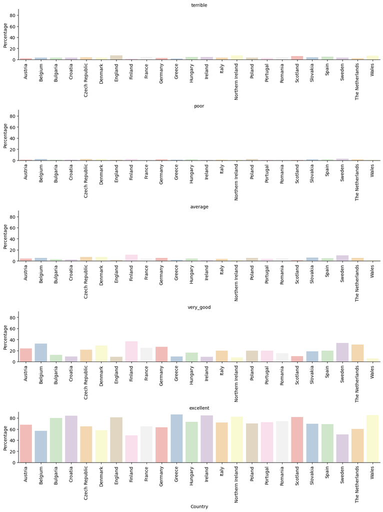

```python
# melting the df so that there are 5 rows for each country for each of the rating categories
pct_df2 = pct_df.reset_index()
long_df = pd.melt(pct_df2, id_vars='country',
                  var_name='rating_category',
                  value_name='percentage')

# creating a facetgrid
g = sns.FacetGrid(long_df, row='rating_category', height=3, aspect=4, sharex=False, sharey=True)

# map the data to a barplot
g.map(sns.barplot, 'country', 'percentage', palette="Pastel1")

# add titles and adjust layout
g.set_axis_labels("Country", "Percentage")
g.set_titles(row_template="{row_name}")
g.set_xticklabels(rotation=90)
g.fig.subplots_adjust(hspace=1)
plt.show()
```

##### Part 1: Supplementary Numeric Representation

```python
# 1) finding which country has the highest percent of restaurants in each respective category
ratings = long_df['rating_category'].unique()
pct_df3 = pct_df.copy()

# looping
for rating in ratings:
    print(rating, pct_df3[rating].nlargest(3).to_string())
    print()

# 2) generalizing to negative ranks vs positive ranks:
# worst restaurants = % ranked terrible + % ranked poor
pct_df3['worst restaurants'] = pct_df3['terrible'] + pct_df3['poor']

# best restaurants = % ranked very_good + % ranked excellent
pct_df3['best restaurants'] = pct_df3['very_good'] + pct_df3['excellent']

# which countries have the worst/best restaurants?
print(pct_df3[['worst restaurants', 'best restaurants']].idxmax(axis=0))
```

```
terrible country
England             7.48
Northern Ireland    7.35
Wales               7.01

poor country
Sweden            2.64
Denmark           2.36
Czech Republic    2.31

average country
Finland           11.29
Sweden            10.04
Czech Republic     7.27

very_good country
Finland    36.70
Sweden     33.67
Belgium    32.54

excellent country
Greece     86.49
Wales      85.46
Ireland    84.87

highest_voted_rating
worst restaurants    Northern Ireland
best restaurants               Greece
dtype: object
```

##### Part 2: Data Wrangling + Visualization

```python
# accessing a map of europe with folium
europe_map = folium.Map(location=[54.5260, 15.2551], zoom_start=4)

# converting the latitude and longitude values to integers
mdata['latitude'] = pd.to_numeric(mdata['latitude'], errors='coerce')
mdata['longitude'] = pd.to_numeric(mdata['longitude'], errors='coerce')

# filtering only for restaurants with the excellent rating and only taking the relevant columns
restaurants = mdata[mdata['highest_voted_rating'] == 'excellent'][['restaurant_name', 'excellent', 'country', 'latitude', 'longitude']]

# to ensure that the map won't be too crowded, only plotting the 3 most voted excellent restaurants per country
top_restaurants = restaurants.sort_values(['country','excellent'], ascending=[True,False]).groupby('country').head(3)

# adding the restaurants to the map
for idx, restaurant in top_restaurants.iterrows():
    folium.Marker(
        location=[restaurant['latitude'], restaurant['longitude']],
        popup=f"{restaurant['restaurant_name'], restaurant['country']}",
        icon=folium.Icon(color='red', icon='info-sign')

    ).add_to(europe_map)

# displaying the map
europe_map
```

Make this Notebook Trusted to load map: File -> Trust Notebook

[interactive chart not shown]

##### Part 2: Numeric Representation

```python
# seeing how many excellent votes each of the top 3 restaurants per country has
top_restaurants[['restaurant_name', 'country', 'excellent']]
```

|  | restaurant_name | country | excellent |
| --- | --- | --- | --- |
| 310235 | Cafe Central | Austria | 3260.0 |
| 312203 | Cafe Sacher Wien | Austria | 2681.0 |
| 311902 | Figlmuller | Austria | 1973.0 |
| 942127 | Park Restaurant | Belgium | 2624.0 |
| 941952 | Ribs 'n Beer | Belgium | 2571.0 |
| 941693 | Brasserie Cambrinus | Belgium | 1599.0 |
| 1072856 | SKAPTO-ISKAR 11A | Bulgaria | 1576.0 |
| 1074593 | Khan's Tent | Bulgaria | 1564.0 |
| 1074590 | Hawaii Restaurant and bar Sunny Beach | Bulgaria | 1504.0 |
| 991827 | Dalmatino | Croatia | 2449.0 |
| 990667 | Taj Mahal | Croatia | 2229.0 |
| 990246 | Bokeria Kitchen & Wine Bar | Croatia | 1917.0 |
| 1032614 | Sad Man's Tongue Bar & Bistro | Czech Republic | 2434.0 |
| 1032771 | Cafe Imperial | Czech Republic | 2242.0 |
| 1036436 | Bellevue | Czech Republic | 2175.0 |
| 1066921 | The Olive Kitchen & Bar | Denmark | 1247.0 |
| 1065393 | Restaurant Tight | Denmark | 1131.0 |
| 1066103 | Høst | Denmark | 1007.0 |
| 519327 | London Steakhouse Co. | England | 7558.0 |
| 529126 | Aqua Shard | England | 7282.0 |
| 544069 | Sotto Sotto | England | 6813.0 |
| 1056514 | Cafe Regatta | Finland | 669.0 |
| 1055901 | Karl Fazer Cafe | Finland | 480.0 |
| 1057462 | Kappeli | Finland | 473.0 |
| 52788 | Angelina | France | 2662.0 |
| 54089 | 58 Tour Eiffel Restaurant | France | 2308.0 |
| 52407 | Sacrée fleur | France | 1728.0 |
| 214664 | Hofbrauhaus | Germany | 5110.0 |
| 224968 | Burgermeister Schlesisches Tor | Germany | 1467.0 |
| 214772 | Augustiner-Keller | Germany | 1210.0 |
| 978629 | Tamam | Greece | 2328.0 |
| 975893 | Argo Restaurant | Greece | 2073.0 |
| 979305 | Avocado Restaurant | Greece | 1994.0 |
| 1051663 | New York Cafe | Hungary | 4012.0 |
| 1050362 | Hungarikum Bisztro | Hungary | 3335.0 |
| 1051277 | Comme Chez Soi | Hungary | 3094.0 |
| 877223 | Queen of Tarts | Ireland | 3111.0 |
| 878861 | The Boxty House | Ireland | 3045.0 |
| 876537 | Market Lane | Ireland | 2387.0 |
| 715157 | Grazia & Graziella | Italy | 4912.0 |
| 712417 | Cantina & Cucina | Italy | 4841.0 |
| 709343 | Tonnarello | Italy | 4473.0 |
| 558267 | Nu Delhi | Northern Ireland | 3016.0 |
| 558594 | The Crown Liquor Saloon | Northern Ireland | 2716.0 |
| 557719 | Mourne Seafood Bar | Northern Ireland | 1936.0 |
| 896810 | Restauracja Starka | Poland | 3120.0 |
| 895993 | Pod Wawelem | Poland | 1325.0 |
| 896156 | Sioux | Poland | 1300.0 |
| 1010326 | Pastéis de Belém | Portugal | 9383.0 |
| 1008528 | Cervejaria Ramiro | Portugal | 2669.0 |
| 1011742 | Restaurante Do Forte | Portugal | 1861.0 |
| 1078478 | Caru' cu bere | Romania | 4757.0 |
| 1077542 | Hard Rock Cafe | Romania | 1603.0 |
| 1077941 | El Torito | Romania | 1164.0 |
| 563046 | The Dome | Scotland | 4110.0 |
| 562964 | Makars Gourmet Mash Bar | Scotland | 3655.0 |
| 563141 | The Kitchin | Scotland | 3168.0 |
| 1029070 | Bratislavsky Mestiansky Pivovar | Slovakia | 693.0 |
| 1029746 | Slovak Pub | Slovakia | 681.0 |
| 1029756 | Modrá Hviezda | Slovakia | 449.0 |
| 460716 | Fado Rock Steak House | Spain | 4790.0 |
| 409846 | Mercado de San Miguel | Spain | 4767.0 |
| 393870 | Cervecería Catalana | Spain | 3352.0 |
| 918382 | Stockholms Gastabud | Sweden | 1001.0 |
| 918376 | Tradition | Sweden | 559.0 |
| 919524 | Restaurang Kryp In Gamla stan | Sweden | 549.0 |
| 166289 | The Seafood Bar van Baerlestraat | The Netherlands | 2500.0 |
| 163523 | Hard Rock Cafe | The Netherlands | 1706.0 |
| 167733 | The Pancake Bakery | The Netherlands | 1646.0 |
| 577858 | The Cottage Loaf | Wales | 2976.0 |
| 556655 | Viva Brazil | Wales | 2346.0 |
| 555031 | The Black Boy Inn | Wales | 1880.0 |